# Time Series - EXAM

## Retrain model on full Power time series and forecast unknown next 96 observations

### SARIMA - Daily period

```r
# SARIMA, daily period
exec_t_start = Sys.time()

fit = Arima(y_daily,
            order = c(5,0,0),
            seasonal = c(0,1,0))
fit |>  summary()
```

```
## Series: y_daily
## ARIMA(5,0,0)(0,1,0)[96]
##
## Coefficients:
##          ar1     ar2     ar3      ar4     ar5
##       0.6699  0.0661  0.1630  -0.2808  0.1322
## s.e.  0.0143  0.0168  0.0167   0.0168  0.0143
##
## sigma^2 = 120.9:  log likelihood = -18297.01
## AIC=36606.01   AICc=36606.03   BIC=36644.86
##
## Training set error measures:
##                      ME     RMSE      MAE        MPE     MAPE      MASE
## Training set -0.1079554 10.87974 6.414877 -0.1535751 2.904919 0.7366183
##                      ACF1
## Training set 0.0005788584
```

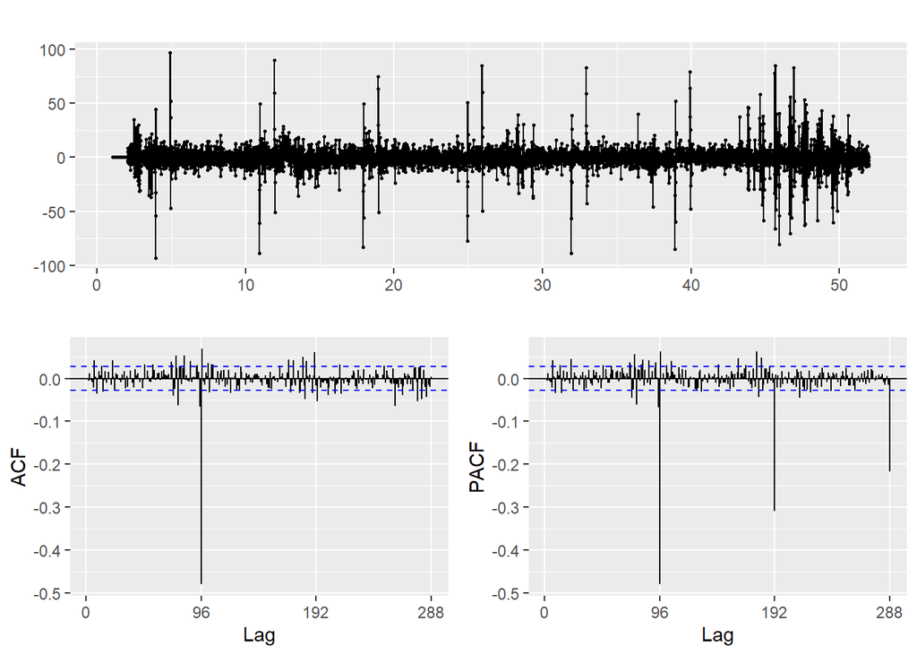

```r
ggtsdisplay(fit$residuals)
```

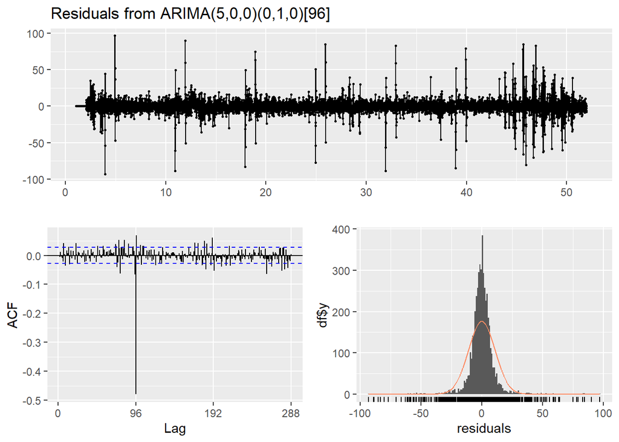

```
##
##  Ljung-Box test
##
## data:  Residuals from ARIMA(5,0,0)(0,1,0)[96]
## Q* = 1571.1, df = 187, p-value < 2.2e-16
##
## Model df: 5.   Total lags used: 192
```

```r
checkresiduals(fit, plot = TRUE)
```

```r
exec_t_end = Sys.time()
print(exec_t_end - exec_t_start)
```

```
## Time difference of 32.74488 secs
```

```r
saveRDS(fit, file = "Final_model_without_covariate_SARIMA_daily.rds")
```

```r
# forecast 96 next values
horizon = 96

prevision_SARIMA = forecast(readRDS("Final_model_without_covariate_SARIMA_daily.rds"), h= horizon)$mean
```

### Random Forest - Daily period

```r
# next observation based on last day
df_daily = as.vector(y_daily)[1:(96+1)]
for (i in 1:(length(y_daily)-(96+1)))
{
  df_daily = rbind(df_daily, as.vector(y_daily)[(i+1):(i+96+1)])
}
```

```r
# train model
exec_t_start = Sys.time()

fit = randomForest(x = df_daily[,-(96+1)], y = df_daily[, (96+1)])
fit |>  summary()
```

```
##                 Length Class  Mode
## call               3   -none- call
## type               1   -none- character
## predicted       4795   -none- numeric
## mse              500   -none- numeric
## rsq              500   -none- numeric
## oob.times       4795   -none- numeric
## importance        96   -none- numeric
## importanceSD       0   -none- NULL
## localImportance    0   -none- NULL
## proximity          0   -none- NULL
## ntree              1   -none- numeric
## mtry               1   -none- numeric
## forest            11   -none- list
## coefs              0   -none- NULL
## y               4795   -none- numeric
## test               0   -none- NULL
## inbag              0   -none- NULL
```

```r
e = ts(fit$y - fit$predicted, start = c(1,6), frequency = 96)
print(paste0("Train RMSE: ", sqrt(mean(e^2, na.rm = TRUE))))
```

```
## [1] "Train RMSE: 7.24713494926096"
```

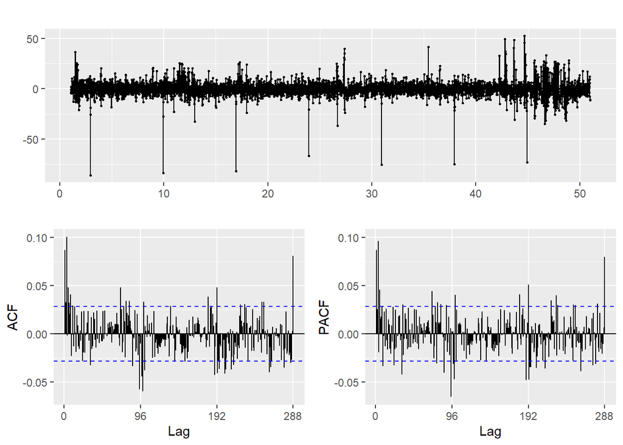

```r
ggtsdisplay(e)
```

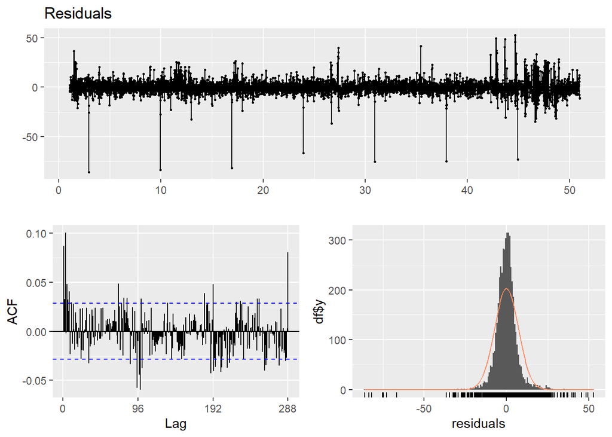

```
##
##  Ljung-Box test
##
## data:  Residuals
## Q* = 399, df = 192, p-value < 2.2e-16
##
## Model df: 0.   Total lags used: 192
```

```r
checkresiduals(e, plot = TRUE)
```

```r
exec_t_end = Sys.time()
print(exec_t_end - exec_t_start)
```

```
## Time difference of 1.445392 mins
```

```r
saveRDS(fit, file = "Final_model_without_covariate_RF_daily.rds")
```

```r
# forecast 96 next values
horizon = 96
newdata_ML = tail(y_daily, horizon)

prevision_RF = ts(
  forecast_ML(readRDS("Final_model_without_covariate_RF_daily.rds"),
              newdata = matrix(newdata_ML,1),
              horizon),
  start = c(52,1),
  frequency = 96)
```

### Forecast plots

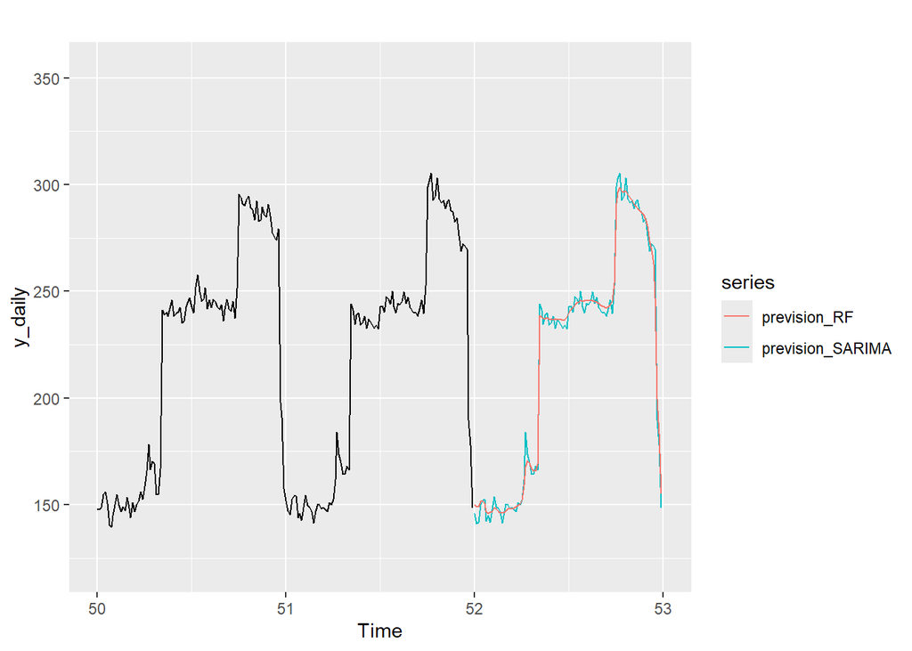

```r
# Plots
autoplot(y_daily) +
  autolayer(prevision_SARIMA) +
  autolayer(prevision_RF)+
  xlim(c(50,53))
```

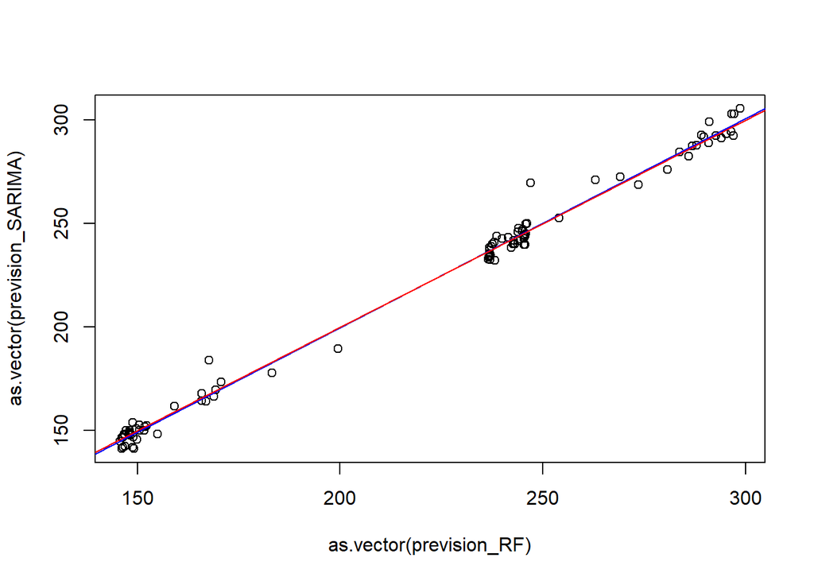

```r
plot(as.vector(prevision_RF), as.vector(prevision_SARIMA))
abline(lm(as.vector(prevision_SARIMA) ~ as.vector(prevision_RF)), col = "blue")
abline(a = 0 , b = 1, col="red")
```

#### Notes:

- RF and SARIMA(5,0,0)(0,1,0)[96] forecast are comparable.
- RF provides a “smoother” forecast, while SARIMA seems better are predicting the short term variability of the time series.

### Save forecast results

```r
df_results = data.frame(Forecast_no_covariate_SARIMA = prevision_SARIMA)
# df_results$Forecast_no_covariate_RF = prevision_RF
```

# Modeling, with co-variates

## Correlation power vs. temperature

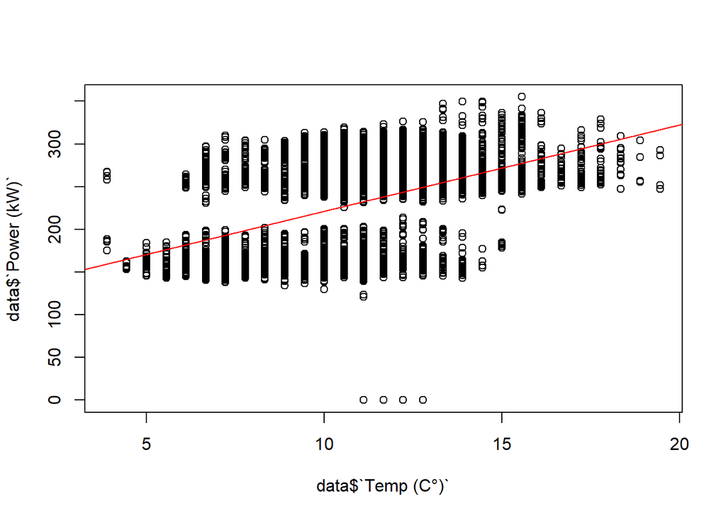

```r
plot(data$`Temp (C°)`, data$`Power (kW)`)
abline(lm(data$`Power (kW)`~data$`Temp (C°)`), col="red")
```

```r
# replace "zero" values
data_impute = data
data_impute[1:length(ts_power_impute), 2] = ts_power_impute

print(paste0("Correlation coef. Power vs. Temp = ", cor(data_impute$`Power (kW)`, data_impute$`Temp (C°)`, use = "complete.obs")))
```

```
## [1] "Correlation coef. Power vs. Temp = 0.4737903811482"
```

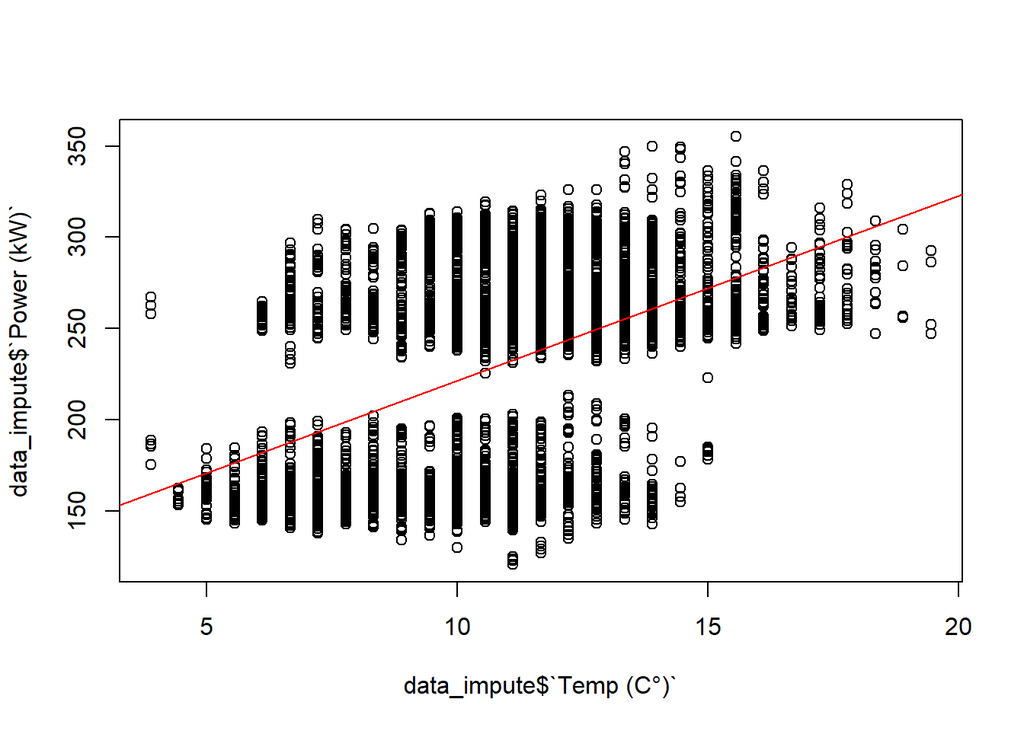

```r
# Plots
plot(data_impute$`Temp (C°)`, data_impute$`Power (kW)`)
abline(lm(data_impute$`Power (kW)`~data_impute$`Temp (C°)`), col="red")
```

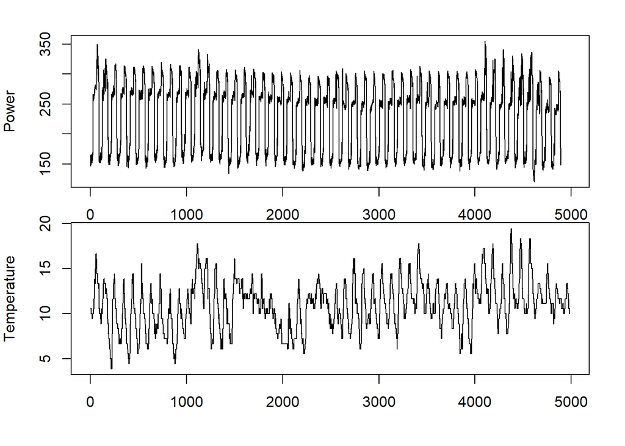

```r
# Set up the layout for 2 rows and 1 column
par(mfrow = c(2, 1), mar = c(0, 4, 2, 2), oma = c(4, 0, 0, 0))

# Plot the first time series
ts.plot(data_impute$`Power (kW)`, xlab = "", ylab = "Power")

# Plot the second time series
par(mar = c(0, 4, 2, 2))  # Adjust margins for the second plot
ts.plot(data_impute$`Temp (C°)`, xlab = "", ylab = "Temperature")
```

```r
# Reset layout
par(mfrow = c(1, 1))
```

#### Notes:

- A correlation exists between Power and Temperature (higher Power is observed when Temperature increases).

## Data preparation

```r
# Convert to time series, daily period
data_impute = ts(data_impute[,2:3], start = c(1,6), frequency = 96)

# Split into train, test and forecast sets
data_train = window(data_impute, end = c(50,96))
data_test = window(data_impute, start = c(51,1), end = c(51,96))
data_forecast = window(data_impute, start = c(52,1))
```

## Dynamic Regression

### Auto-ARIMA with covariate

```r
# Auto SARIMA, daily period, with covariate
exec_t_start = Sys.time()

fit = auto.arima(data_train[,1], xreg = data_train[,2])
fit |>  summary()
```

```
## Series: data_train[, 1]
## Regression with ARIMA(5,0,0)(0,1,0)[96] errors
##
## Coefficients:
##          ar1     ar2     ar3      ar4     ar5    xreg
##       0.6676  0.0680  0.1606  -0.2828  0.1307  0.6002
## s.e.  0.0145  0.0169  0.0168   0.0169  0.0145  0.2279
##
## sigma^2 = 122.6:  log likelihood = -17963.38
## AIC=35940.76   AICc=35940.78   BIC=35985.94
##
## Training set error measures:
##                      ME     RMSE     MAE        MPE     MAPE     MASE
## Training set -0.1053383 10.95349 6.45461 -0.1548071 2.920209 0.734121
##                      ACF1
## Training set 0.0008102879
```

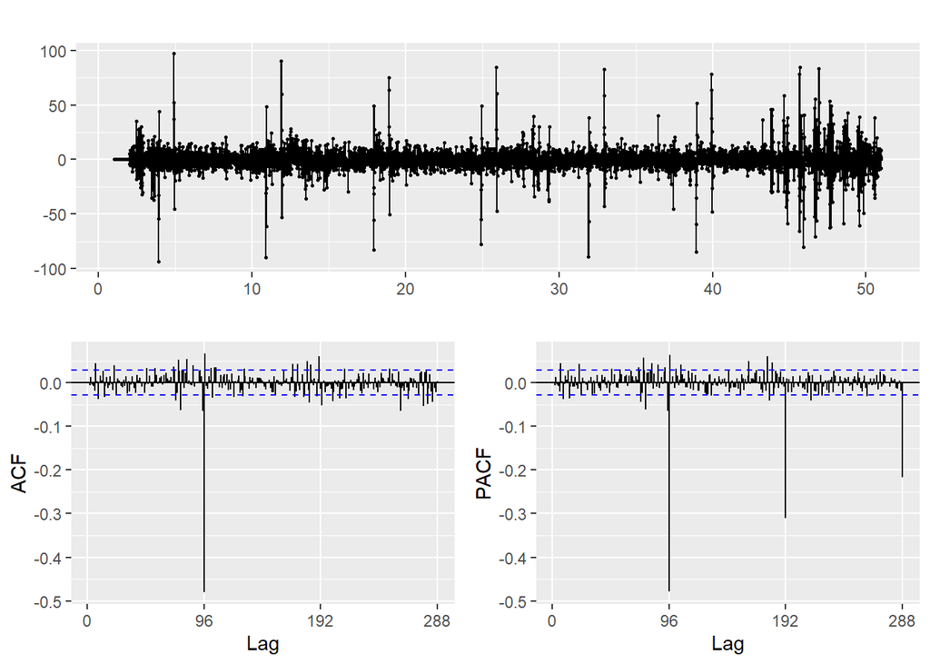

```r
ggtsdisplay(fit$residuals)
```

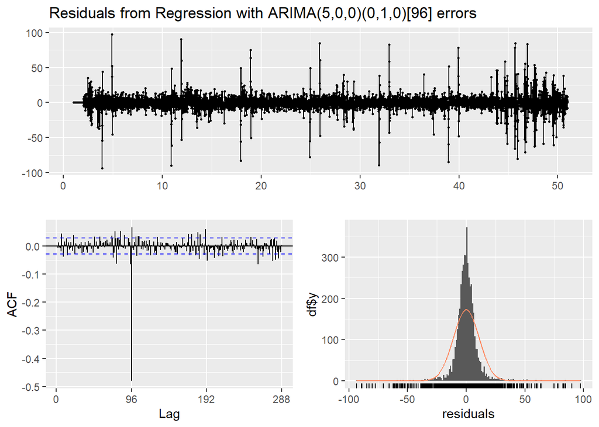

```
##
##  Ljung-Box test
##
## data:  Residuals from Regression with ARIMA(5,0,0)(0,1,0)[96] errors
## Q* = 1542.2, df = 187, p-value < 2.2e-16
##
## Model df: 5.   Total lags used: 192
```

```r
checkresiduals(fit, plot = TRUE)
```

```r
exec_t_end = Sys.time()
print(exec_t_end - exec_t_start)
```

```
## Time difference of 1.303488 mins
```

```r
# Prediction on test set
prevision = forecast(fit, h = 96, xreg = data_test[,2])$mean
cat(paste0("Test RMSE: ", RMSE(data_test[,1], prevision)))
```

```
## Test RMSE: 5.94262743321338
```

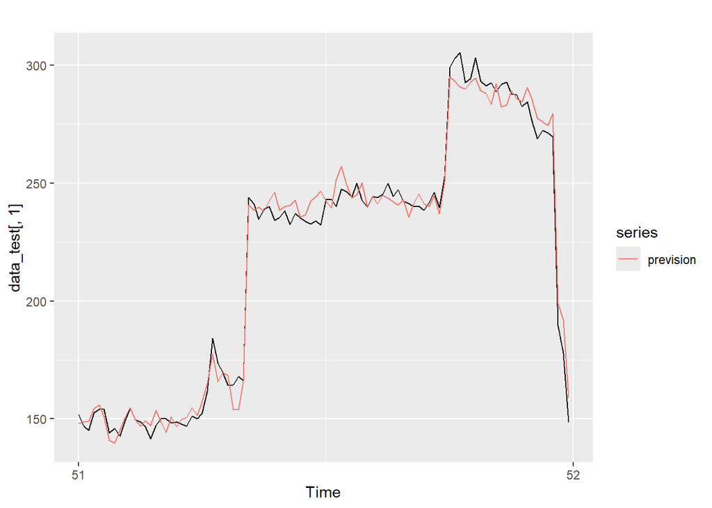

```r
autoplot(data_test[,1]) +
  autolayer(prevision)
```

#### Notes:

- ACF shows significant autocorrelation at 96 (= 1 day period) and PACF shows exponentially decreasing autocorrelation for daily periods -> try adding seasonal MA (Q = 1)

```r
# saveRDS(fit, file = "ARIMA_X_auto_(5,0,0)(0,1,0)[96].rds")
```

#### Cross-validation

```r
# Code commented: very long computation

# # Cross validation using tsCV(), ref: https://pkg.robjhyndman.com/forecast/reference/tsCV.html
#
# # Forcasting function to cross-validate
# Arima_xreg <- function(x, h, xreg, newxreg) {
#   forecast(Arima(x,
#                  order=c(5,0,0),
#                  seasonal = c(0,1,0),
#                  xreg=xreg),
#            xreg=newxreg)
# }
#
# # Crossvalidation execution
# exec_t_start = Sys.time()
#
# e <- tsCV(data_impute[,1], Arima_xreg, h=96, xreg=data_impute[,2], window = 4795)
#
# exec_t_end = Sys.time()
# print(exec_t_end - exec_t_start)
#
# print(paste0("Cross-validation RMSE: ", sqrt(mean(e^2, na.rm = TRUE))))
```

#### Notes:

- Cross validation:

  ```r
  Arima_xreg <- function(x, h, xreg, newxreg)
    {
    forecast(Arima(x,
                   order=c(5,0,0),
                   seasonal = c(0,1,0),
                   xreg=xreg), xreg=newxreg)
    }

  e <- tsCV(data_impute[,1], Arima_xreg, h=96, xreg=data_impute[,2], window = 4795)

  print(paste0("Cross-validation RMSE: ", sqrt(mean(e^2, na.rm = TRUE))))
  ```

- Results:

  ```
  Time difference of 3.731499 hours
  [1] "Cross-validation RMSE: 6.5453262433807"
  ```

### Investigate linear modeling using `tslm()`

```r
exec_t_start = Sys.time()

fit = tslm(data_train[,1] ~ data_train[,2] + trend + season, data = data_train)
fit |> summary()
```

```
##
## Call:
## tslm(formula = data_train[, 1] ~ data_train[, 2] + trend + season,
##     data = data_train)
##
## Residuals:
##      Min       1Q   Median       3Q      Max
## -115.518   -5.356    0.001    4.999   62.334
##
## Coefficients:
##                   Estimate Std. Error t value Pr(>|t|)
## (Intercept)      1.515e+02  2.004e+00  75.610  < 2e-16 ***
## data_train[, 2]  1.414e+00  9.515e-02  14.859  < 2e-16 ***
## trend           -3.446e-03  1.385e-04 -24.883  < 2e-16 ***
## season2         -4.376e-01  2.522e+00  -0.174  0.86226
## season3         -5.958e+00  2.522e+00  -2.362  0.01820 *
## season4         -3.820e-01  2.522e+00  -0.151  0.87960
## season5          2.732e+00  2.522e+00   1.083  0.27867
## season6          2.595e+00  2.510e+00   1.034  0.30129
## season7         -6.207e+00  2.510e+00  -2.473  0.01343 *
## season8         -6.511e+00  2.510e+00  -2.594  0.00951 **
## season9         -3.483e+00  2.510e+00  -1.388  0.16532
## season10        -3.474e+00  2.510e+00  -1.384  0.16651
## season11        -1.017e+00  2.510e+00  -0.405  0.68533
## season12        -1.773e+00  2.510e+00  -0.706  0.48005
## season13        -5.155e-01  2.510e+00  -0.205  0.83730
## season14        -4.476e+00  2.511e+00  -1.782  0.07478 .
## season15        -5.968e+00  2.511e+00  -2.377  0.01752 *
## season16        -3.247e-01  2.511e+00  -0.129  0.89712
## season17         1.615e+00  2.511e+00   0.643  0.52028
## season18         6.386e-01  2.513e+00   0.254  0.79939
## season19        -2.900e-01  2.513e+00  -0.115  0.90813
## season20         8.475e-01  2.513e+00   0.337  0.73592
## season21         9.889e-01  2.513e+00   0.394  0.69391
## season22         2.009e+00  2.513e+00   0.799  0.42409
## season23         2.717e+00  2.513e+00   1.081  0.27980
## season24         4.524e+00  2.513e+00   1.800  0.07192 .
## season25         4.574e+00  2.513e+00   1.820  0.06887 .
## season26         7.737e+00  2.513e+00   3.079  0.00209 **
## season27         1.532e+01  2.513e+00   6.095 1.18e-09 ***
```

[output cut: 60 more lines]

```
## season88         1.323e+02  2.510e+00  52.721  < 2e-16 ***
## season89         1.304e+02  2.510e+00  51.940  < 2e-16 ***
## season90         1.139e+02  2.509e+00  45.406  < 2e-16 ***
## season91         1.121e+02  2.509e+00  44.673  < 2e-16 ***
## season92         1.069e+02  2.509e+00  42.615  < 2e-16 ***
## season93         1.077e+02  2.509e+00  42.912  < 2e-16 ***
## season94         3.234e+01  2.509e+00  12.889  < 2e-16 ***
## season95         3.331e+01  2.509e+00  13.274  < 2e-16 ***
## season96         3.113e+00  2.509e+00   1.241  0.21485
## ---
## Signif. codes:  0 '***' 0.001 '**' 0.01 '*' 0.05 '.' 0.1 ' ' 1
##
## Residual standard error: 12.48 on 4697 degrees of freedom
## Multiple R-squared:  0.9542, Adjusted R-squared:  0.9532
## F-statistic:  1008 on 97 and 4697 DF,  p-value: < 2.2e-16
```

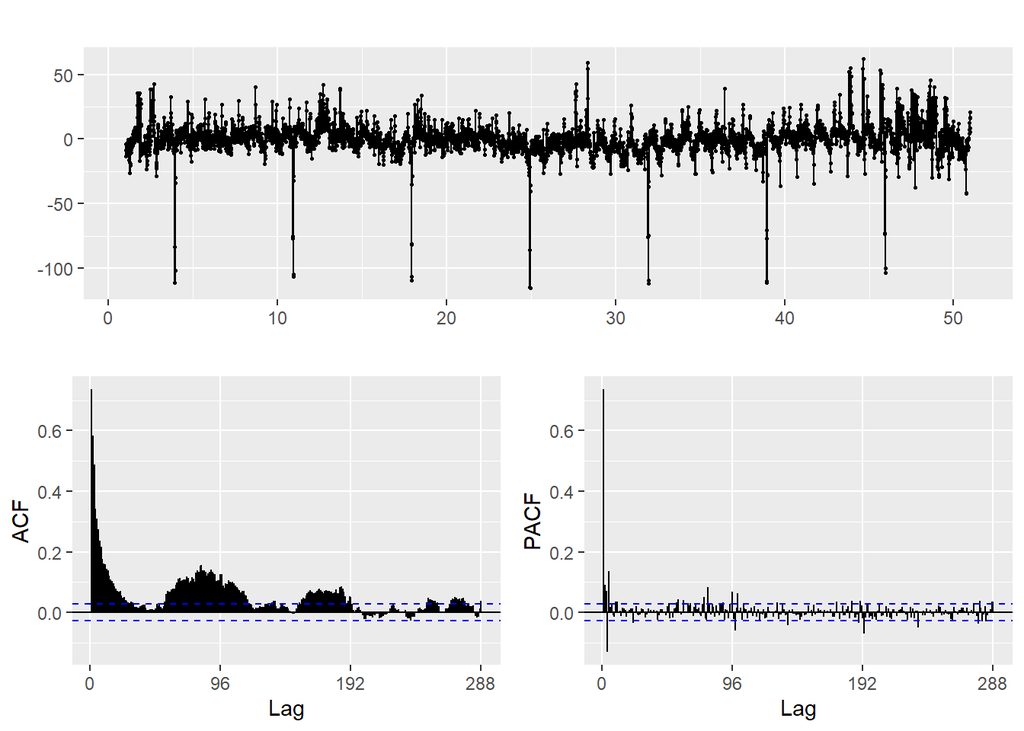

```r
ggtsdisplay(fit$residuals)
```

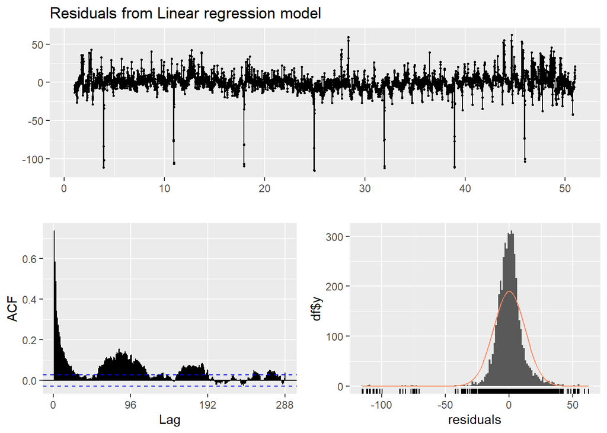

```
##
##  Breusch-Godfrey test for serial correlation of order up to 192
##
## data:  Residuals from Linear regression model
## LM test = 2857, df = 192, p-value < 2.2e-16
```

```r
checkresiduals(fit, plot = TRUE)
```

```r
exec_t_end = Sys.time()
print(exec_t_end - exec_t_start)
```

```
## Time difference of 2.198074 secs
```

### Fit manually ARIMA with covariate

```r
# SARIMA, daily period
exec_t_start = Sys.time()

fit = Arima(data_train[,1],
            xreg = data_train[,-1],
            order = c(5,0,0),
            seasonal = c(0,1,1))
fit |>  summary()
```

```
## Series: data_train[, 1]
## Regression with ARIMA(5,0,0)(0,1,1)[96] errors
##
## Coefficients:
##          ar1     ar2     ar3      ar4     ar5     sma1    xreg
##       0.6692  0.0689  0.1616  -0.2370  0.1239  -0.8742  0.6670
## s.e.  0.0145  0.0171  0.0170   0.0171  0.0145   0.0076  0.2162
##
## sigma^2 = 67.56:  log likelihood = -16632.24
## AIC=33280.48   AICc=33280.51   BIC=33332.12
##
## Training set error measures:
##                      ME     RMSE      MAE        MPE     MAPE     MASE
## Training set -0.3843715 8.130442 4.992301 -0.2785698 2.259614 0.567804
##                      ACF1
## Training set -0.005122333
```

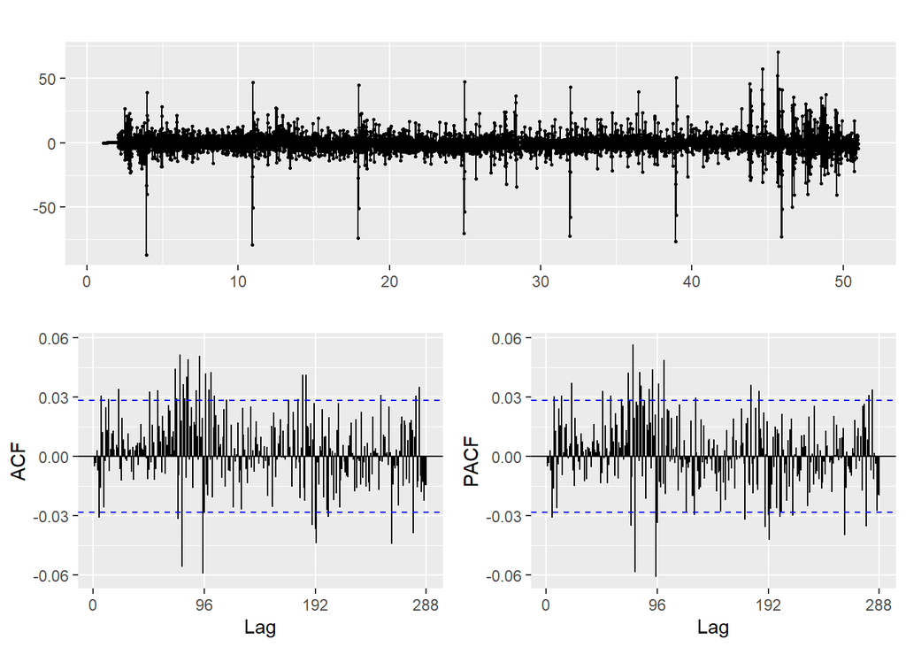

```r
ggtsdisplay(fit$residuals)
```

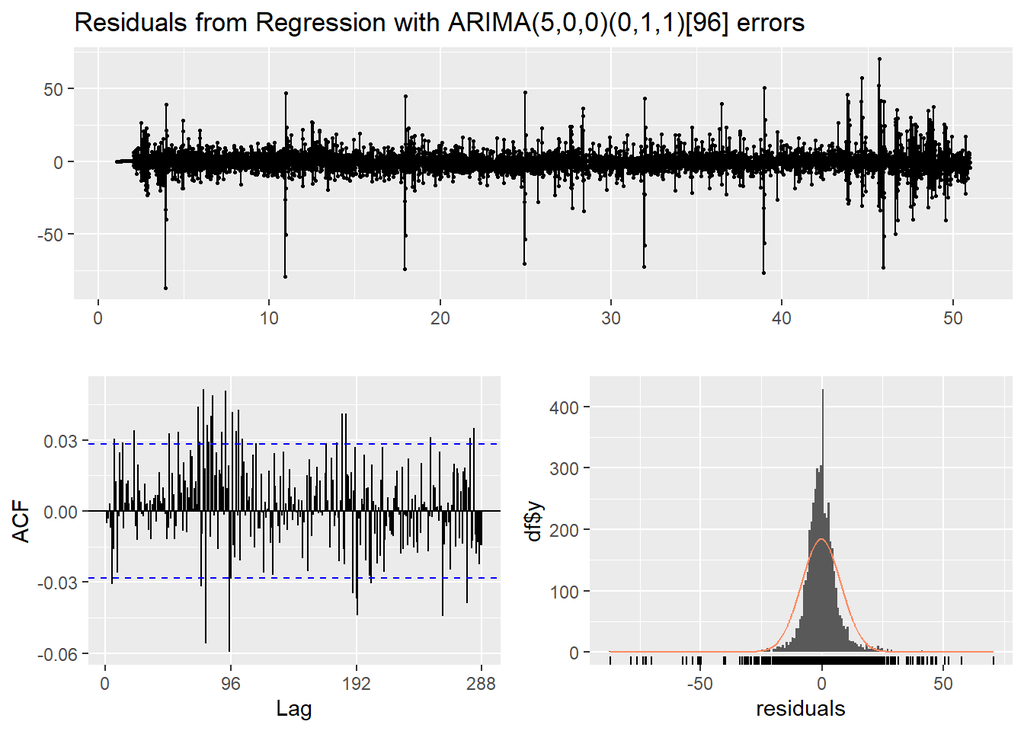

```
##
##  Ljung-Box test
##
## data:  Residuals from Regression with ARIMA(5,0,0)(0,1,1)[96] errors
## Q* = 338.49, df = 186, p-value = 5.767e-11
##
## Model df: 6.   Total lags used: 192
```

```r
checkresiduals(fit, plot = TRUE)
```

```r
exec_t_end = Sys.time()
print(exec_t_end - exec_t_start)
```

```
## Time difference of 5.972807 mins
```

```r
# Prediction on test set
prevision = forecast(fit, h = 96, xreg = data_test[,2])$mean
cat(paste0("Test RMSE: ", RMSE(data_test[,1], prevision)))
```

```
## Test RMSE: 11.5012990199773
```

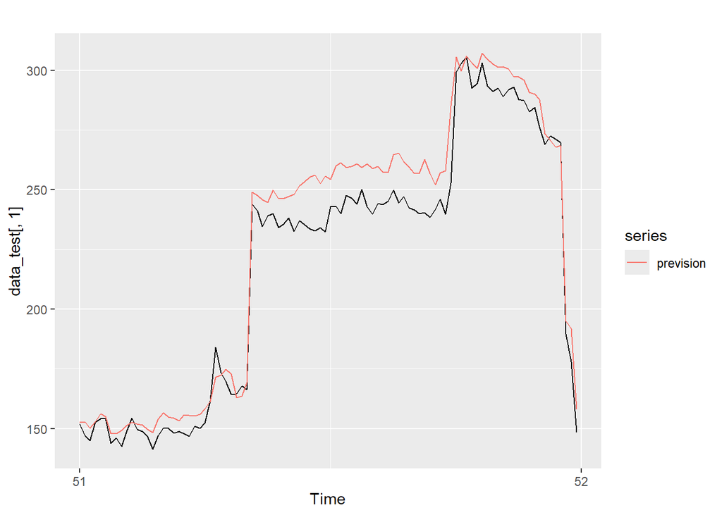

```r
autoplot(data_test[,1]) +
  autolayer(prevision)
```

```r
# saveRDS(fit, file = "ARIMA_X_auto_(5,0,0)(0,1,1)[96].rds")
```

## ML modeling

### ML Data prep

```r
# next observation based on last day
df_daily_covariate = as.vector(data_train[1:(96+1),])
for (i in 1:(dim(data_train)[1]-(96+1)))
{
  df_daily_covariate = rbind(df_daily_covariate,
                             as.vector(data_train[(i+1):(i+96+1),]))
}
```

### Random Forest

```r
exec_t_start = Sys.time()

fit = randomForest(x = df_daily_covariate[,-(96+1)],
                   y = df_daily_covariate[,(96+1)])
fit |>  summary()
```

```
##                 Length Class  Mode
## call               3   -none- call
## type               1   -none- character
## predicted       4699   -none- numeric
## mse              500   -none- numeric
## rsq              500   -none- numeric
## oob.times       4699   -none- numeric
## importance       193   -none- numeric
## importanceSD       0   -none- NULL
## localImportance    0   -none- NULL
## proximity          0   -none- NULL
## ntree              1   -none- numeric
## mtry               1   -none- numeric
## forest            11   -none- list
## coefs              0   -none- NULL
## y               4699   -none- numeric
## test               0   -none- NULL
## inbag              0   -none- NULL
```

```r
e = ts(fit$y - fit$predicted, start = c(1,6), frequency = 96)
print(paste0("Train RMSE: ", sqrt(mean(e^2, na.rm = TRUE))))
```

```
## [1] "Train RMSE: 7.23889974531755"
```

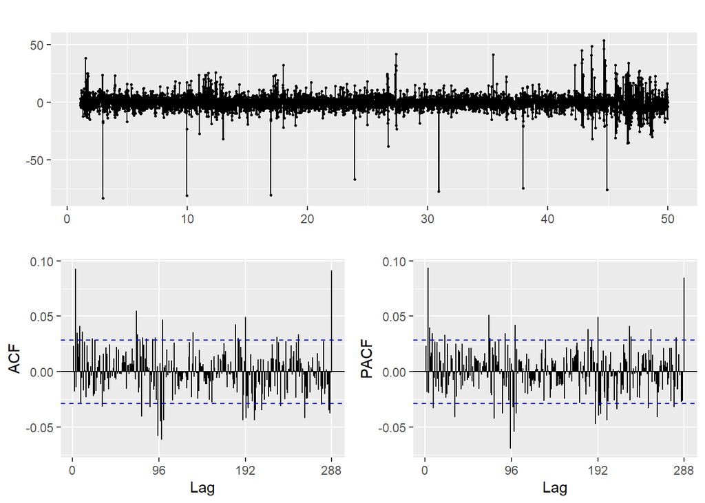

```r
ggtsdisplay(e)
```

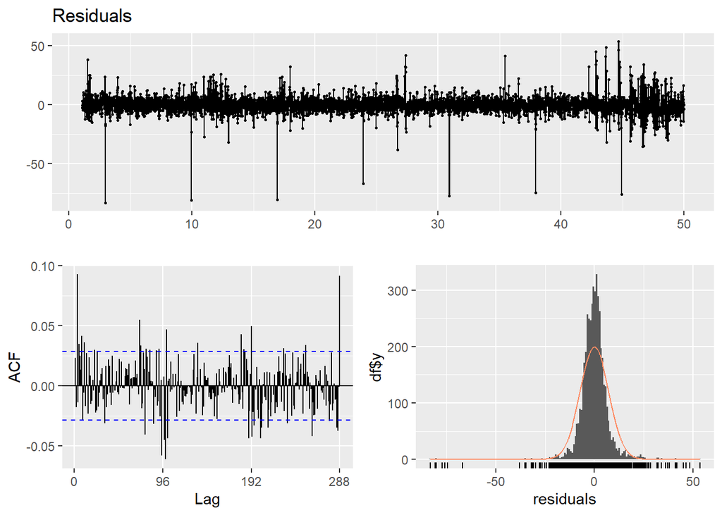

```
##
##  Ljung-Box test
##
## data:  Residuals
## Q* = 371.7, df = 192, p-value = 1.41e-13
##
## Model df: 0.   Total lags used: 192
```

```r
checkresiduals(e, plot = TRUE)
```

```r
exec_t_end = Sys.time()
print(exec_t_end - exec_t_start)
```

```
## Time difference of 2.562062 mins
```

```r
# saveRDS(fit, file = "RF_X_daily.rds")
```

## Model performance comparison

```r
# Build a list of models
models_list = list()
models_list$SARIMA_X_500_010_96 = readRDS('ARIMA_X_auto_(5,0,0)(0,1,0)[96].rds')
models_list$SARIMA_X_500_011_96 = readRDS('ARIMA_X_auto_(5,0,0)(0,1,1)[96].rds')
models_list$RF_X_daily = readRDS('RF_X_daily.rds')

# Make predictions with each model and store RMSE
previsions_list = list()
rmsep_list = list()
horizon = 96
freq = 96
newdata_ML = c(as.vector(tail(data_train, 96)))
xreg = as.vector(data_test[,2])

for (name in names(models_list))
{
  cat(paste0("Forcasting model:", name, "\n"))

  if(grepl("RF", name) | grepl("XG", name)) # Use forecast_ML_X() with ML models
  {
    prevision = forecast_ML_X(models_list[[name]],
                              newdata = matrix(newdata_ML,1),
                              horizon,
                              xreg = xreg)
    prevision = ts(prevision,
                   start = start(data_test),
                   frequency = freq)
  }
  else # Use forecast() with ts models
  {
    prevision = forecast(models_list[[name]], h = horizon, xreg = xreg)
    prevision = prevision$mean
  }

  previsions_list[[name]] = prevision
  rmsep_list[[name]] = RMSE(y_daily_test,prevision)

  cat(paste0("Test set RMSE: ", rmsep_list[[name]], "\n\n"))
}
```

```
## Forcasting model:SARIMA_X_500_010_96
## Test set RMSE: 5.94262743321338
##
## Forcasting model:SARIMA_X_500_011_96
## Test set RMSE: 11.5012990199773
##
## Forcasting model:RF_X_daily
## Test set RMSE: 7.74487203111378
```

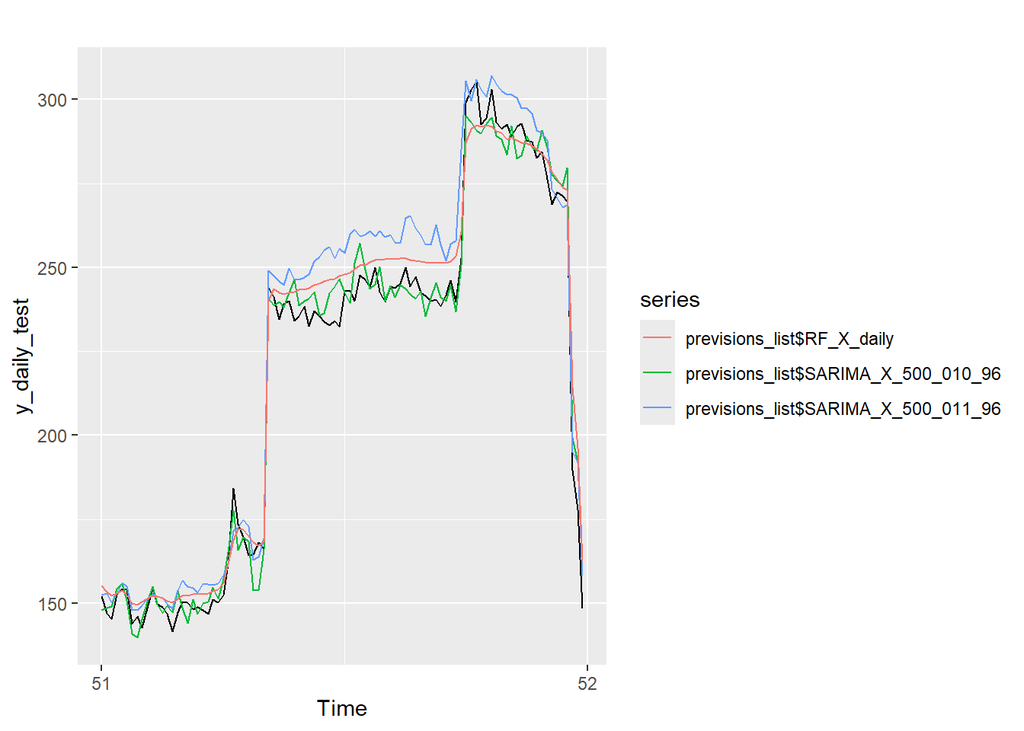

```r
# Plots
autoplot(y_daily_test) +
  autolayer(previsions_list$SARIMA_X_500_010_96) +
  autolayer(previsions_list$SARIMA_X_500_011_96) +
  autolayer(previsions_list$RF_X_daily)
```

## Retrain model on full Power time series and forecast unknown next 96 observations, using Temperature as covariate

### SARIMA - Daily period

```r
# SARIMA, daily period
exec_t_start = Sys.time()

fit = Arima(head(data_impute, dim(data_impute)[1]-96)[,1],
            xreg = head(data_impute, dim(data_impute)[1]-96)[,-1],
            order = c(5,0,0),
            seasonal = c(0,1,0))
fit |>  summary()
```

```
## Series: head(data_impute, dim(data_impute)[1] - 96)[, 1]
## Regression with ARIMA(5,0,0)(0,1,0)[96] errors
##
## Coefficients:
##          ar1     ar2     ar3      ar4     ar5    xreg
##       0.6670  0.0670  0.1613  -0.2812  0.1299  0.5990
## s.e.  0.0143  0.0168  0.0166   0.0168  0.0143  0.2248
##
## sigma^2 = 120.7:  log likelihood = -18293.52
## AIC=36601.04   AICc=36601.06   BIC=36646.37
##
## Training set error measures:
##                     ME     RMSE      MAE        MPE     MAPE      MASE
## Training set -0.107984 10.87185 6.412602 -0.1545285 2.903275 0.7363569
##                      ACF1
## Training set 0.0008750915
```

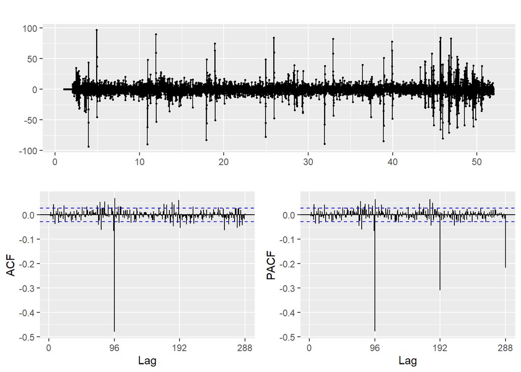

```r
ggtsdisplay(fit$residuals)
```

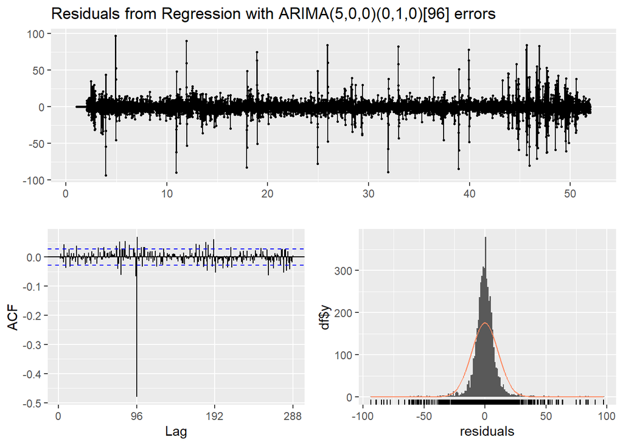

```
##
##  Ljung-Box test
##
## data:  Residuals from Regression with ARIMA(5,0,0)(0,1,0)[96] errors
## Q* = 1573.6, df = 187, p-value < 2.2e-16
##
## Model df: 5.   Total lags used: 192
```

```r
checkresiduals(fit, plot = TRUE)
```

```r
exec_t_end = Sys.time()
print(exec_t_end - exec_t_start)
```

```
## Time difference of 43.25694 secs
```

```r
saveRDS(fit, file = "Final_model_with_covariate_SARIMA_daily.rds")
```

```r
# forecast 96 next values
horizon = 96

prevision_SARIMA_X = forecast(readRDS("Final_model_with_covariate_SARIMA_daily.rds"), h= horizon, xreg = data_forecast[,-1])$mean
```

### Random Forest - Daily period

```r
# next observation based on last day
df_daily_covariate = as.vector(data_impute[1:(96+1),])

for (i in 1:(dim(data_impute)[1]-(96+1+96)))
{
  df_daily_covariate = rbind(df_daily_covariate,
                             as.vector(data_impute[(i+1):(i+96+1),]))
}
```

```r
exec_t_start = Sys.time()

fit = randomForest(x = df_daily_covariate[,-(96+1)],
                   y = df_daily_covariate[,(96+1)])
fit |>  summary()
```

```
##                 Length Class  Mode
## call               3   -none- call
## type               1   -none- character
## predicted       4795   -none- numeric
## mse              500   -none- numeric
## rsq              500   -none- numeric
## oob.times       4795   -none- numeric
## importance       193   -none- numeric
## importanceSD       0   -none- NULL
## localImportance    0   -none- NULL
## proximity          0   -none- NULL
## ntree              1   -none- numeric
## mtry               1   -none- numeric
## forest            11   -none- list
## coefs              0   -none- NULL
## y               4795   -none- numeric
## test               0   -none- NULL
## inbag              0   -none- NULL
```

```r
e = ts(fit$y - fit$predicted, start = c(1,6), frequency = 96)
print(paste0("Train RMSE: ", sqrt(mean(e^2, na.rm = TRUE))))
```

```
## [1] "Train RMSE: 7.20633022987013"
```

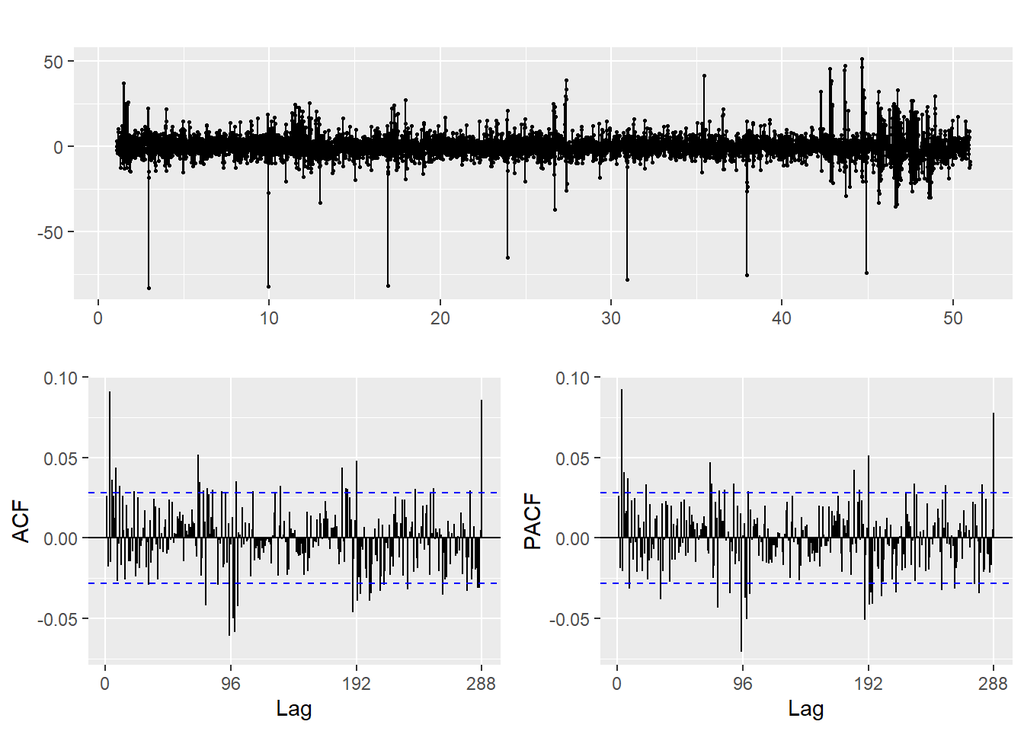

```r
ggtsdisplay(e)
```

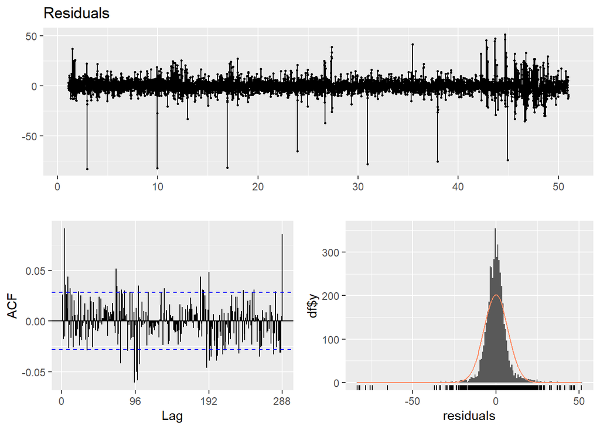

```
##
##  Ljung-Box test
##
## data:  Residuals
## Q* = 372.09, df = 192, p-value = 1.278e-13
##
## Model df: 0.   Total lags used: 192
```

```r
checkresiduals(e, plot = TRUE)
```

```r
exec_t_end = Sys.time()
print(exec_t_end - exec_t_start)
```

```
## Time difference of 2.599786 mins
```

```r
saveRDS(fit, file = "Final_model_with_covariate_RF_daily.rds")
```

```r
# forecast 96 next values
horizon = 96
freq = 96
newdata_ML = c(as.vector(window(data_impute, start = c(51,1), end = c(51,96))))
xreg = as.vector(data_forecast[,2])

prevision_RF_X = ts(
  forecast_ML_X(readRDS("Final_model_with_covariate_RF_daily.rds"),
              newdata = matrix(newdata_ML,1),
              horizon,
              xreg),
  start = c(52,1),
  frequency = freq)
```

### Plots

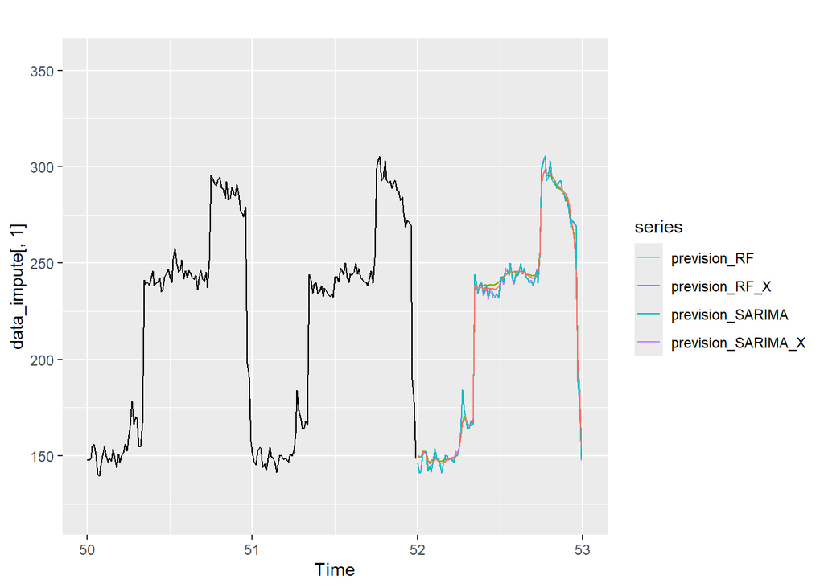

```r
# Plots
autoplot(data_impute[,1]) +
  autolayer(prevision_SARIMA_X) +
  autolayer(prevision_RF_X) +
  autolayer(prevision_SARIMA) +
  autolayer(prevision_RF) +
  xlim(c(50,53))
```

### Save forecast results

```r
df_results$Forecast_covariate_SARIMA = prevision_SARIMA_X
# df_results$Forecast_covariate_RF = prevision_RF_X
```

# Export forecast results

```r
write_xlsx(df_results, "SamdGuizani.xlsx", col_names = FALSE)
```